# Risk Factor Analysis

## Outcome Variable

**Outcome Variable:** y_rate_wtkg

## Predictor Variables

**Intervention Variable:** exclfeed6

**Adjustment Set:**

- arm
- sex
- brthmon
- W_mage
- meducyrs
- feducyrs
- hhwealth_quart
- hfoodsec
- W_mhtcm
- W_mwtkg
- W_mbmi
- vagbrth
- W_birthwt
- W_birthlen
- W_nrooms
- month
- W_parity
- impfloor
- impsan
- safeh20
- delta_W_mage
- delta_meducyrs
- delta_feducyrs
- delta_hhwealth_quart
- delta_hfoodsec
- delta_W_mhtcm
- delta_W_mwtkg
- delta_W_mbmi
- delta_vagbrth
- delta_W_birthwt
- delta_W_birthlen
- delta_W_nrooms
- delta_month
- delta_W_parity
- delta_impfloor
- delta_impsan
- delta_safeh20

## Stratifying Variables

The analysis was stratified on these variable(s):

- agecat
- studyid
- country

## Data Summary

| agecat | studyid | country | exclfeed6 | n_cell | n | outcome_variable |
| --- | --- | --- | --- | --- | --- | --- |
| 0-3 months | ki0047075b-MAL-ED | BANGLADESH | 1 | 33 | 230 | y_rate_wtkg |
| 0-3 months | ki0047075b-MAL-ED | BANGLADESH | 0 | 197 | 230 | y_rate_wtkg |
| 0-3 months | ki0047075b-MAL-ED | BRAZIL | 1 | 12 | 210 | y_rate_wtkg |
| 0-3 months | ki0047075b-MAL-ED | BRAZIL | 0 | 198 | 210 | y_rate_wtkg |
| 0-3 months | ki0047075b-MAL-ED | INDIA | 1 | 2 | 216 | y_rate_wtkg |
| 0-3 months | ki0047075b-MAL-ED | INDIA | 0 | 214 | 216 | y_rate_wtkg |
| 0-3 months | ki0047075b-MAL-ED | NEPAL | 1 | 4 | 219 | y_rate_wtkg |
| 0-3 months | ki0047075b-MAL-ED | NEPAL | 0 | 215 | 219 | y_rate_wtkg |
| 0-3 months | ki0047075b-MAL-ED | PERU | 1 | 5 | 270 | y_rate_wtkg |
| 0-3 months | ki0047075b-MAL-ED | PERU | 0 | 265 | 270 | y_rate_wtkg |
| 0-3 months | ki0047075b-MAL-ED | SOUTH AFRICA | 1 | 0 | 234 | y_rate_wtkg |
| 0-3 months | ki0047075b-MAL-ED | SOUTH AFRICA | 0 | 234 | 234 | y_rate_wtkg |
| 0-3 months | ki0047075b-MAL-ED | TANZANIA, UNITED REPUBLIC OF | 1 | 0 | 219 | y_rate_wtkg |
| 0-3 months | ki0047075b-MAL-ED | TANZANIA, UNITED REPUBLIC OF | 0 | 219 | 219 | y_rate_wtkg |
| 0-3 months | ki1000108-CMC-V-BCS-2002 | INDIA | 1 | 16 | 16 | y_rate_wtkg |
| 0-3 months | ki1000108-CMC-V-BCS-2002 | INDIA | 0 | 0 | 16 | y_rate_wtkg |
| 0-3 months | ki1000108-IRC | INDIA | 1 | 0 | 14 | y_rate_wtkg |
| 0-3 months | ki1000108-IRC | INDIA | 0 | 14 | 14 | y_rate_wtkg |
| 0-3 months | ki1000109-EE | PAKISTAN | 1 | 35 | 39 | y_rate_wtkg |
| 0-3 months | ki1000109-EE | PAKISTAN | 0 | 4 | 39 | y_rate_wtkg |
| 0-3 months | ki1000304b-SAS-CompFeed | INDIA | 1 | 413 | 435 | y_rate_wtkg |
| 0-3 months | ki1000304b-SAS-CompFeed | INDIA | 0 | 22 | 435 | y_rate_wtkg |
| 0-3 months | ki1017093b-PROVIDE | BANGLADESH | 1 | 159 | 640 | y_rate_wtkg |
| 0-3 months | ki1017093b-PROVIDE | BANGLADESH | 0 | 481 | 640 | y_rate_wtkg |
| 0-3 months | ki1101329-Keneba | GAMBIA | 1 | 474 | 1491 | y_rate_wtkg |
| 0-3 months | ki1101329-Keneba | GAMBIA | 0 | 1017 | 1491 | y_rate_wtkg |
| 0-3 months | ki1113344-GMS-Nepal | NEPAL | 1 | 368 | 501 | y_rate_wtkg |
| 0-3 months | ki1113344-GMS-Nepal | NEPAL | 0 | 133 | 501 | y_rate_wtkg |
| 0-3 months | kiGH5241-JiVitA-3 | BANGLADESH | 1 | 9426 | 12207 | y_rate_wtkg |
| 0-3 months | kiGH5241-JiVitA-3 | BANGLADESH | 0 | 2781 | 12207 | y_rate_wtkg |

[output cut: 226 more lines]

The following strata were considered:

- agecat: 0-3 months, studyid: ki0047075b-MAL-ED, country: BANGLADESH
- agecat: 0-3 months, studyid: ki0047075b-MAL-ED, country: BRAZIL
- agecat: 0-3 months, studyid: ki0047075b-MAL-ED, country: INDIA
- agecat: 0-3 months, studyid: ki0047075b-MAL-ED, country: NEPAL
- agecat: 0-3 months, studyid: ki0047075b-MAL-ED, country: PERU
- agecat: 0-3 months, studyid: ki0047075b-MAL-ED, country: SOUTH AFRICA
- agecat: 0-3 months, studyid: ki0047075b-MAL-ED, country: TANZANIA, UNITED REPUBLIC OF
- agecat: 0-3 months, studyid: ki1000108-CMC-V-BCS-2002, country: INDIA
- agecat: 0-3 months, studyid: ki1000108-IRC, country: INDIA
- agecat: 0-3 months, studyid: ki1000109-EE, country: PAKISTAN
- agecat: 0-3 months, studyid: ki1000304b-SAS-CompFeed, country: INDIA
- agecat: 0-3 months, studyid: ki1017093b-PROVIDE, country: BANGLADESH
- agecat: 0-3 months, studyid: ki1101329-Keneba, country: GAMBIA
- agecat: 0-3 months, studyid: ki1113344-GMS-Nepal, country: NEPAL
- agecat: 0-3 months, studyid: kiGH5241-JiVitA-3, country: BANGLADESH
- agecat: 0-3 months, studyid: kiGH5241-JiVitA-4, country: BANGLADESH
- agecat: 12-15 months, studyid: ki0047075b-MAL-ED, country: BANGLADESH
- agecat: 12-15 months, studyid: ki0047075b-MAL-ED, country: BRAZIL
- agecat: 12-15 months, studyid: ki0047075b-MAL-ED, country: INDIA
- agecat: 12-15 months, studyid: ki0047075b-MAL-ED, country: NEPAL
- agecat: 12-15 months, studyid: ki0047075b-MAL-ED, country: PERU
- agecat: 12-15 months, studyid: ki0047075b-MAL-ED, country: SOUTH AFRICA
- agecat: 12-15 months, studyid: ki0047075b-MAL-ED, country: TANZANIA, UNITED REPUBLIC OF
- agecat: 12-15 months, studyid: ki1000108-CMC-V-BCS-2002, country: INDIA
- agecat: 12-15 months, studyid: ki1000108-IRC, country: INDIA
- agecat: 12-15 months, studyid: ki1000109-EE, country: PAKISTAN
- agecat: 12-15 months, studyid: ki1000304b-SAS-CompFeed, country: INDIA
- agecat: 12-15 months, studyid: ki1000304b-SAS-FoodSuppl, country: INDIA
- agecat: 12-15 months, studyid: ki1017093b-PROVIDE, country: BANGLADESH
- agecat: 12-15 months, studyid: ki1101329-Keneba, country: GAMBIA
- agecat: 12-15 months, studyid: ki1113344-GMS-Nepal, country: NEPAL
- agecat: 12-15 months, studyid: ki1148112-LCNI-5, country: MALAWI
- agecat: 12-15 months, studyid: kiGH5241-JiVitA-4, country: BANGLADESH
- agecat: 15-18 months, studyid: ki0047075b-MAL-ED, country: BANGLADESH
- agecat: 15-18 months, studyid: ki0047075b-MAL-ED, country: BRAZIL
- agecat: 15-18 months, studyid: ki0047075b-MAL-ED, country: INDIA
- agecat: 15-18 months, studyid: ki0047075b-MAL-ED, country: NEPAL
- agecat: 15-18 months, studyid: ki0047075b-MAL-ED, country: PERU
- agecat: 15-18 months, studyid: ki0047075b-MAL-ED, country: SOUTH AFRICA
- agecat: 15-18 months, studyid: ki0047075b-MAL-ED, country: TANZANIA, UNITED REPUBLIC OF
- agecat: 15-18 months, studyid: ki1000108-CMC-V-BCS-2002, country: INDIA
- agecat: 15-18 months, studyid: ki1000108-IRC, country: INDIA
- agecat: 15-18 months, studyid: ki1000109-EE, country: PAKISTAN
- agecat: 15-18 months, studyid: ki1000304b-SAS-CompFeed, country: INDIA
- agecat: 15-18 months, studyid: ki1000304b-SAS-FoodSuppl, country: INDIA
- agecat: 15-18 months, studyid: ki1017093b-PROVIDE, country: BANGLADESH
- agecat: 15-18 months, studyid: ki1101329-Keneba, country: GAMBIA
- agecat: 15-18 months, studyid: ki1113344-GMS-Nepal, country: NEPAL
- agecat: 15-18 months, studyid: ki1148112-LCNI-5, country: MALAWI
- agecat: 15-18 months, studyid: kiGH5241-JiVitA-4, country: BANGLADESH
- agecat: 18-21 months, studyid: ki0047075b-MAL-ED, country: BANGLADESH
- agecat: 18-21 months, studyid: ki0047075b-MAL-ED, country: BRAZIL
- agecat: 18-21 months, studyid: ki0047075b-MAL-ED, country: INDIA
- agecat: 18-21 months, studyid: ki0047075b-MAL-ED, country: NEPAL
- agecat: 18-21 months, studyid: ki0047075b-MAL-ED, country: PERU
- agecat: 18-21 months, studyid: ki0047075b-MAL-ED, country: SOUTH AFRICA
- agecat: 18-21 months, studyid: ki0047075b-MAL-ED, country: TANZANIA, UNITED REPUBLIC OF
- agecat: 18-21 months, studyid: ki1000108-CMC-V-BCS-2002, country: INDIA
- agecat: 18-21 months, studyid: ki1000108-IRC, country: INDIA
- agecat: 18-21 months, studyid: ki1000109-EE, country: PAKISTAN
- agecat: 18-21 months, studyid: ki1017093b-PROVIDE, country: BANGLADESH
- agecat: 18-21 months, studyid: ki1101329-Keneba, country: GAMBIA
- agecat: 18-21 months, studyid: ki1113344-GMS-Nepal, country: NEPAL
- agecat: 18-21 months, studyid: ki1148112-LCNI-5, country: MALAWI
- agecat: 21-24 months, studyid: ki0047075b-MAL-ED, country: BANGLADESH
- agecat: 21-24 months, studyid: ki0047075b-MAL-ED, country: BRAZIL
- agecat: 21-24 months, studyid: ki0047075b-MAL-ED, country: INDIA
- agecat: 21-24 months, studyid: ki0047075b-MAL-ED, country: NEPAL
- agecat: 21-24 months, studyid: ki0047075b-MAL-ED, country: PERU
- agecat: 21-24 months, studyid: ki0047075b-MAL-ED, country: SOUTH AFRICA
- agecat: 21-24 months, studyid: ki0047075b-MAL-ED, country: TANZANIA, UNITED REPUBLIC OF
- agecat: 21-24 months, studyid: ki1000108-CMC-V-BCS-2002, country: INDIA
- agecat: 21-24 months, studyid: ki1000108-IRC, country: INDIA
- agecat: 21-24 months, studyid: ki1000109-EE, country: PAKISTAN
- agecat: 21-24 months, studyid: ki1017093b-PROVIDE, country: BANGLADESH
- agecat: 21-24 months, studyid: ki1101329-Keneba, country: GAMBIA
- agecat: 21-24 months, studyid: ki1113344-GMS-Nepal, country: NEPAL
- agecat: 21-24 months, studyid: ki1148112-LCNI-5, country: MALAWI
- agecat: 3-6 months, studyid: ki0047075b-MAL-ED, country: BANGLADESH
- agecat: 3-6 months, studyid: ki0047075b-MAL-ED, country: BRAZIL
- agecat: 3-6 months, studyid: ki0047075b-MAL-ED, country: INDIA
- agecat: 3-6 months, studyid: ki0047075b-MAL-ED, country: NEPAL
- agecat: 3-6 months, studyid: ki0047075b-MAL-ED, country: PERU
- agecat: 3-6 months, studyid: ki0047075b-MAL-ED, country: SOUTH AFRICA
- agecat: 3-6 months, studyid: ki0047075b-MAL-ED, country: TANZANIA, UNITED REPUBLIC OF
- agecat: 3-6 months, studyid: ki1000108-CMC-V-BCS-2002, country: INDIA
- agecat: 3-6 months, studyid: ki1000108-IRC, country: INDIA
- agecat: 3-6 months, studyid: ki1000109-EE, country: PAKISTAN
- agecat: 3-6 months, studyid: ki1000304b-SAS-CompFeed, country: INDIA
- agecat: 3-6 months, studyid: ki1017093b-PROVIDE, country: BANGLADESH
- agecat: 3-6 months, studyid: ki1101329-Keneba, country: GAMBIA
- agecat: 3-6 months, studyid: ki1113344-GMS-Nepal, country: NEPAL
- agecat: 3-6 months, studyid: kiGH5241-JiVitA-3, country: BANGLADESH
- agecat: 3-6 months, studyid: kiGH5241-JiVitA-4, country: BANGLADESH
- agecat: 6-9 months, studyid: ki0047075b-MAL-ED, country: BANGLADESH
- agecat: 6-9 months, studyid: ki0047075b-MAL-ED, country: BRAZIL
- agecat: 6-9 months, studyid: ki0047075b-MAL-ED, country: INDIA
- agecat: 6-9 months, studyid: ki0047075b-MAL-ED, country: NEPAL
- agecat: 6-9 months, studyid: ki0047075b-MAL-ED, country: PERU
- agecat: 6-9 months, studyid: ki0047075b-MAL-ED, country: SOUTH AFRICA
- agecat: 6-9 months, studyid: ki0047075b-MAL-ED, country: TANZANIA, UNITED REPUBLIC OF
- agecat: 6-9 months, studyid: ki1000108-CMC-V-BCS-2002, country: INDIA
- agecat: 6-9 months, studyid: ki1000108-IRC, country: INDIA
- agecat: 6-9 months, studyid: ki1000109-EE, country: PAKISTAN
- agecat: 6-9 months, studyid: ki1000304b-SAS-CompFeed, country: INDIA
- agecat: 6-9 months, studyid: ki1000304b-SAS-FoodSuppl, country: INDIA
- agecat: 6-9 months, studyid: ki1017093b-PROVIDE, country: BANGLADESH
- agecat: 6-9 months, studyid: ki1101329-Keneba, country: GAMBIA
- agecat: 6-9 months, studyid: ki1113344-GMS-Nepal, country: NEPAL
- agecat: 6-9 months, studyid: ki1148112-LCNI-5, country: MALAWI
- agecat: 6-9 months, studyid: kiGH5241-JiVitA-4, country: BANGLADESH
- agecat: 9-12 months, studyid: ki0047075b-MAL-ED, country: BANGLADESH
- agecat: 9-12 months, studyid: ki0047075b-MAL-ED, country: BRAZIL
- agecat: 9-12 months, studyid: ki0047075b-MAL-ED, country: INDIA
- agecat: 9-12 months, studyid: ki0047075b-MAL-ED, country: NEPAL
- agecat: 9-12 months, studyid: ki0047075b-MAL-ED, country: PERU
- agecat: 9-12 months, studyid: ki0047075b-MAL-ED, country: SOUTH AFRICA
- agecat: 9-12 months, studyid: ki0047075b-MAL-ED, country: TANZANIA, UNITED REPUBLIC OF
- agecat: 9-12 months, studyid: ki1000108-CMC-V-BCS-2002, country: INDIA
- agecat: 9-12 months, studyid: ki1000108-IRC, country: INDIA
- agecat: 9-12 months, studyid: ki1000109-EE, country: PAKISTAN
- agecat: 9-12 months, studyid: ki1000304b-SAS-CompFeed, country: INDIA
- agecat: 9-12 months, studyid: ki1000304b-SAS-FoodSuppl, country: INDIA
- agecat: 9-12 months, studyid: ki1017093b-PROVIDE, country: BANGLADESH
- agecat: 9-12 months, studyid: ki1101329-Keneba, country: GAMBIA
- agecat: 9-12 months, studyid: ki1113344-GMS-Nepal, country: NEPAL
- agecat: 9-12 months, studyid: ki1148112-LCNI-5, country: MALAWI
- agecat: 9-12 months, studyid: kiGH5241-JiVitA-4, country: BANGLADESH

### Dropped Strata

Some strata were dropped due to rare outcomes:

- agecat: 0-3 months, studyid: ki0047075b-MAL-ED, country: INDIA
- agecat: 0-3 months, studyid: ki0047075b-MAL-ED, country: NEPAL
- agecat: 0-3 months, studyid: ki0047075b-MAL-ED, country: SOUTH AFRICA
- agecat: 0-3 months, studyid: ki0047075b-MAL-ED, country: TANZANIA, UNITED REPUBLIC OF
- agecat: 0-3 months, studyid: ki1000108-CMC-V-BCS-2002, country: INDIA
- agecat: 0-3 months, studyid: ki1000108-IRC, country: INDIA
- agecat: 0-3 months, studyid: ki1000109-EE, country: PAKISTAN
- agecat: 3-6 months, studyid: ki0047075b-MAL-ED, country: INDIA
- agecat: 3-6 months, studyid: ki0047075b-MAL-ED, country: NEPAL
- agecat: 3-6 months, studyid: ki0047075b-MAL-ED, country: SOUTH AFRICA
- agecat: 3-6 months, studyid: ki0047075b-MAL-ED, country: TANZANIA, UNITED REPUBLIC OF
- agecat: 3-6 months, studyid: ki1000108-CMC-V-BCS-2002, country: INDIA
- agecat: 3-6 months, studyid: ki1000108-IRC, country: INDIA
- agecat: 3-6 months, studyid: ki1000109-EE, country: PAKISTAN
- agecat: 6-9 months, studyid: ki0047075b-MAL-ED, country: INDIA
- agecat: 6-9 months, studyid: ki0047075b-MAL-ED, country: SOUTH AFRICA
- agecat: 6-9 months, studyid: ki0047075b-MAL-ED, country: TANZANIA, UNITED REPUBLIC OF
- agecat: 6-9 months, studyid: ki1000108-CMC-V-BCS-2002, country: INDIA
- agecat: 6-9 months, studyid: ki1000108-IRC, country: INDIA
- agecat: 6-9 months, studyid: ki1000304b-SAS-FoodSuppl, country: INDIA
- agecat: 9-12 months, studyid: ki0047075b-MAL-ED, country: INDIA
- agecat: 9-12 months, studyid: ki0047075b-MAL-ED, country: NEPAL
- agecat: 9-12 months, studyid: ki0047075b-MAL-ED, country: SOUTH AFRICA
- agecat: 9-12 months, studyid: ki0047075b-MAL-ED, country: TANZANIA, UNITED REPUBLIC OF
- agecat: 9-12 months, studyid: ki1000108-CMC-V-BCS-2002, country: INDIA
- agecat: 9-12 months, studyid: ki1000108-IRC, country: INDIA
- agecat: 9-12 months, studyid: ki1000304b-SAS-FoodSuppl, country: INDIA
- agecat: 12-15 months, studyid: ki0047075b-MAL-ED, country: INDIA
- agecat: 12-15 months, studyid: ki0047075b-MAL-ED, country: NEPAL
- agecat: 12-15 months, studyid: ki0047075b-MAL-ED, country: PERU
- agecat: 12-15 months, studyid: ki0047075b-MAL-ED, country: SOUTH AFRICA
- agecat: 12-15 months, studyid: ki0047075b-MAL-ED, country: TANZANIA, UNITED REPUBLIC OF
- agecat: 12-15 months, studyid: ki1000108-CMC-V-BCS-2002, country: INDIA
- agecat: 12-15 months, studyid: ki1000108-IRC, country: INDIA
- agecat: 12-15 months, studyid: ki1000304b-SAS-FoodSuppl, country: INDIA
- agecat: 12-15 months, studyid: ki1148112-LCNI-5, country: MALAWI
- agecat: 15-18 months, studyid: ki0047075b-MAL-ED, country: INDIA
- agecat: 15-18 months, studyid: ki0047075b-MAL-ED, country: PERU
- agecat: 15-18 months, studyid: ki0047075b-MAL-ED, country: SOUTH AFRICA
- agecat: 15-18 months, studyid: ki0047075b-MAL-ED, country: TANZANIA, UNITED REPUBLIC OF
- agecat: 15-18 months, studyid: ki1000108-CMC-V-BCS-2002, country: INDIA
- agecat: 15-18 months, studyid: ki1000108-IRC, country: INDIA
- agecat: 15-18 months, studyid: ki1000304b-SAS-FoodSuppl, country: INDIA
- agecat: 15-18 months, studyid: ki1148112-LCNI-5, country: MALAWI
- agecat: 18-21 months, studyid: ki0047075b-MAL-ED, country: INDIA
- agecat: 18-21 months, studyid: ki0047075b-MAL-ED, country: PERU
- agecat: 18-21 months, studyid: ki0047075b-MAL-ED, country: SOUTH AFRICA
- agecat: 18-21 months, studyid: ki0047075b-MAL-ED, country: TANZANIA, UNITED REPUBLIC OF
- agecat: 18-21 months, studyid: ki1000108-CMC-V-BCS-2002, country: INDIA
- agecat: 18-21 months, studyid: ki1000108-IRC, country: INDIA
- agecat: 21-24 months, studyid: ki0047075b-MAL-ED, country: INDIA
- agecat: 21-24 months, studyid: ki0047075b-MAL-ED, country: PERU
- agecat: 21-24 months, studyid: ki0047075b-MAL-ED, country: SOUTH AFRICA
- agecat: 21-24 months, studyid: ki0047075b-MAL-ED, country: TANZANIA, UNITED REPUBLIC OF
- agecat: 21-24 months, studyid: ki1000108-CMC-V-BCS-2002, country: INDIA
- agecat: 21-24 months, studyid: ki1000108-IRC, country: INDIA
- agecat: 21-24 months, studyid: ki1000109-EE, country: PAKISTAN

## Methods Detail

We’re interested in the causal parameters $E[Y_a]$ for all values of $a \in \mathcal{A}$. These parameters represent the mean outcome if, possibly contrary to fact, we intervened to set all units to have $A=a$. Under the randomization and positivity assumptions, these are identified by the statistical parameters $\psi_a=E_W[E_{Y|A,W}(Y|A=a,W)]$. In addition, we’re interested in the mean of $Y$, $E[Y]$ under no intervention (the observed mean). We will estimate these parameters by using SuperLearner to fit the relevant likelihood factors – $E_{Y|A,W}(Y|A=a,W)$ and $p(A=a|W)$, and then updating our likelihood fit using a joint TMLE.

For unadjusted analyses ($W=\{\}$), initial likelihoods were estimated using Lrnr_glm to estimate the simple $E(Y|A)$ and Lrnr_mean to estimate $p(A)$. For adjusted analyses, a small library containing Lrnr_glmnet, Lrnr_xgboost, and Lrnr_mean was used.

# Results Detail

## Results Plots

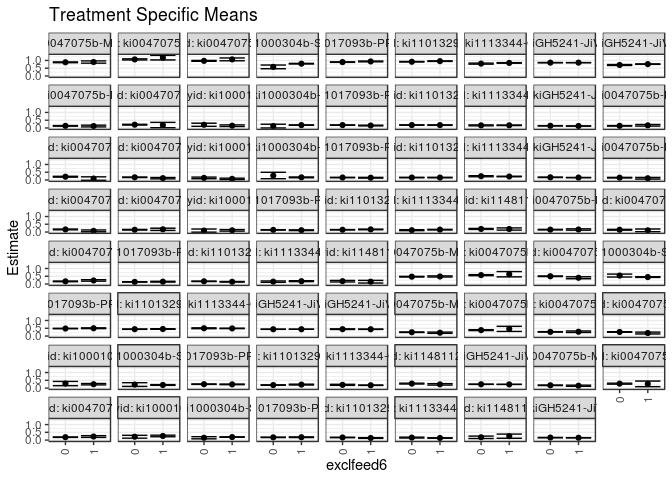

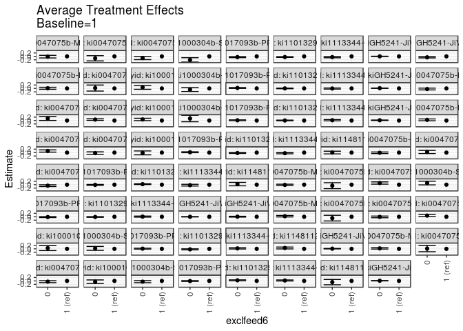

[figure not shown]

## Results Table

### Parameter: TSM

| agecat | studyid | country | intervention_level | baseline_level | estimate | ci_lower | ci_upper |
| --- | --- | --- | --- | --- | --- | --- | --- |
| 0-3 months | ki0047075b-MAL-ED | BANGLADESH | 1 | NA | 0.8964435 | 0.8237935 | 0.9690936 |
| 0-3 months | ki0047075b-MAL-ED | BANGLADESH | 0 | NA | 0.8801414 | 0.8541714 | 0.9061115 |
| 0-3 months | ki0047075b-MAL-ED | BRAZIL | 1 | NA | 1.1785435 | 1.0307413 | 1.3263457 |
| 0-3 months | ki0047075b-MAL-ED | BRAZIL | 0 | NA | 1.0647228 | 1.0291259 | 1.1003198 |
| 0-3 months | ki0047075b-MAL-ED | PERU | 1 | NA | 1.0676347 | 0.9782686 | 1.1570008 |
| 0-3 months | ki0047075b-MAL-ED | PERU | 0 | NA | 0.9704594 | 0.9440671 | 0.9968518 |
| 0-3 months | ki1000304b-SAS-CompFeed | INDIA | 1 | NA | 0.7909090 | 0.7730413 | 0.8087768 |
| 0-3 months | ki1000304b-SAS-CompFeed | INDIA | 0 | NA | 0.5848960 | 0.4650105 | 0.7047816 |
| 0-3 months | ki1017093b-PROVIDE | BANGLADESH | 1 | NA | 0.9347792 | 0.9079576 | 0.9616009 |
| 0-3 months | ki1017093b-PROVIDE | BANGLADESH | 0 | NA | 0.8914475 | 0.8740050 | 0.9088901 |
| 0-3 months | ki1101329-Keneba | GAMBIA | 1 | NA | 0.9536471 | 0.9347141 | 0.9725801 |
| 0-3 months | ki1101329-Keneba | GAMBIA | 0 | NA | 0.9136472 | 0.8995231 | 0.9277714 |
| 0-3 months | ki1113344-GMS-Nepal | NEPAL | 1 | NA | 0.8385407 | 0.8188585 | 0.8582229 |
| 0-3 months | ki1113344-GMS-Nepal | NEPAL | 0 | NA | 0.7949062 | 0.7606567 | 0.8291556 |
| 0-3 months | kiGH5241-JiVitA-3 | BANGLADESH | 1 | NA | 0.8566405 | 0.8526362 | 0.8606449 |
| 0-3 months | kiGH5241-JiVitA-3 | BANGLADESH | 0 | NA | 0.8572353 | 0.8503269 | 0.8641438 |
| 0-3 months | kiGH5241-JiVitA-4 | BANGLADESH | 1 | NA | 0.7626835 | 0.7480551 | 0.7773119 |
| 0-3 months | kiGH5241-JiVitA-4 | BANGLADESH | 0 | NA | 0.7065692 | 0.6746098 | 0.7385286 |
| 3-6 months | ki0047075b-MAL-ED | BANGLADESH | 1 | NA | 0.4864479 | 0.4496004 | 0.5232955 |
| 3-6 months | ki0047075b-MAL-ED | BANGLADESH | 0 | NA | 0.4731715 | 0.4535271 | 0.4928160 |
| 3-6 months | ki0047075b-MAL-ED | BRAZIL | 1 | NA | 0.6328772 | 0.4618862 | 0.8038683 |
| 3-6 months | ki0047075b-MAL-ED | BRAZIL | 0 | NA | 0.5745024 | 0.5427476 | 0.6062572 |
| 3-6 months | ki0047075b-MAL-ED | PERU | 1 | NA | 0.4036505 | 0.3414661 | 0.4658349 |
| 3-6 months | ki0047075b-MAL-ED | PERU | 0 | NA | 0.5004995 | 0.4811397 | 0.5198593 |
| 3-6 months | ki1000304b-SAS-CompFeed | INDIA | 1 | NA | 0.4486193 | 0.4260666 | 0.4711720 |
| 3-6 months | ki1000304b-SAS-CompFeed | INDIA | 0 | NA | 0.5450975 | 0.4502057 | 0.6399893 |
| 3-6 months | ki1017093b-PROVIDE | BANGLADESH | 1 | NA | 0.5030512 | 0.4778700 | 0.5282325 |
| 3-6 months | ki1017093b-PROVIDE | BANGLADESH | 0 | NA | 0.4854371 | 0.4701860 | 0.5006882 |
| 3-6 months | ki1101329-Keneba | GAMBIA | 1 | NA | 0.4547725 | 0.4374727 | 0.4720723 |
| 3-6 months | ki1101329-Keneba | GAMBIA | 0 | NA | 0.4430652 | 0.4317214 | 0.4544091 |

[output cut: 112 more lines]

### Parameter: E(Y)

| agecat | studyid | country | intervention_level | baseline_level | estimate | ci_lower | ci_upper |
| --- | --- | --- | --- | --- | --- | --- | --- |
| 0-3 months | ki0047075b-MAL-ED | BANGLADESH | NA | NA | 0.8815161 | 0.8573098 | 0.9057224 |
| 0-3 months | ki0047075b-MAL-ED | BRAZIL | NA | NA | 1.0702868 | 1.0355019 | 1.1050717 |
| 0-3 months | ki0047075b-MAL-ED | PERU | NA | NA | 0.9722590 | 0.9463823 | 0.9981357 |
| 0-3 months | ki1000304b-SAS-CompFeed | INDIA | NA | NA | 0.7852849 | 0.7678149 | 0.8027549 |
| 0-3 months | ki1017093b-PROVIDE | BANGLADESH | NA | NA | 0.9016472 | 0.8868914 | 0.9164029 |
| 0-3 months | ki1101329-Keneba | GAMBIA | NA | NA | 0.9263104 | 0.9149216 | 0.9376991 |
| 0-3 months | ki1113344-GMS-Nepal | NEPAL | NA | NA | 0.8262343 | 0.8091204 | 0.8433482 |
| 0-3 months | kiGH5241-JiVitA-3 | BANGLADESH | NA | NA | 0.8567813 | 0.8531554 | 0.8604071 |
| 0-3 months | kiGH5241-JiVitA-4 | BANGLADESH | NA | NA | 0.7536287 | 0.7402358 | 0.7670217 |
| 3-6 months | ki0047075b-MAL-ED | BANGLADESH | NA | NA | 0.4752798 | 0.4582021 | 0.4923576 |
| 3-6 months | ki0047075b-MAL-ED | BRAZIL | NA | NA | 0.5781976 | 0.5469697 | 0.6094254 |
| 3-6 months | ki0047075b-MAL-ED | PERU | NA | NA | 0.4986791 | 0.4796733 | 0.5176848 |
| 3-6 months | ki1000304b-SAS-CompFeed | INDIA | NA | NA | 0.4538554 | 0.4355388 | 0.4721719 |
| 3-6 months | ki1017093b-PROVIDE | BANGLADESH | NA | NA | 0.4890611 | 0.4760060 | 0.5021163 |
| 3-6 months | ki1101329-Keneba | GAMBIA | NA | NA | 0.4467297 | 0.4371593 | 0.4563000 |
| 3-6 months | ki1113344-GMS-Nepal | NEPAL | NA | NA | 0.4969184 | 0.4830319 | 0.5108048 |
| 3-6 months | kiGH5241-JiVitA-3 | BANGLADESH | NA | NA | 0.4401107 | 0.4363074 | 0.4439140 |
| 3-6 months | kiGH5241-JiVitA-4 | BANGLADESH | NA | NA | 0.4390246 | 0.4301757 | 0.4478736 |
| 6-9 months | ki0047075b-MAL-ED | BANGLADESH | NA | NA | 0.2415793 | 0.2267676 | 0.2563910 |
| 6-9 months | ki0047075b-MAL-ED | BRAZIL | NA | NA | 0.3831499 | 0.3570859 | 0.4092138 |
| 6-9 months | ki0047075b-MAL-ED | NEPAL | NA | NA | 0.2701634 | 0.2553060 | 0.2850207 |
| 6-9 months | ki0047075b-MAL-ED | PERU | NA | NA | 0.2613933 | 0.2459015 | 0.2768851 |
| 6-9 months | ki1000109-EE | PAKISTAN | NA | NA | 0.2545881 | 0.2127069 | 0.2964693 |
| 6-9 months | ki1000304b-SAS-CompFeed | INDIA | NA | NA | 0.2018620 | 0.1756088 | 0.2281152 |
| 6-9 months | ki1017093b-PROVIDE | BANGLADESH | NA | NA | 0.2491653 | 0.2371134 | 0.2612172 |
| 6-9 months | ki1101329-Keneba | GAMBIA | NA | NA | 0.2019457 | 0.1892538 | 0.2146377 |
| 6-9 months | ki1113344-GMS-Nepal | NEPAL | NA | NA | 0.1872663 | 0.1750716 | 0.1994611 |
| 6-9 months | ki1148112-LCNI-5 | MALAWI | NA | NA | 0.2829175 | 0.2578313 | 0.3080037 |
| 6-9 months | kiGH5241-JiVitA-4 | BANGLADESH | NA | NA | 0.2387113 | 0.2332818 | 0.2441408 |
| 9-12 months | ki0047075b-MAL-ED | BANGLADESH | NA | NA | 0.1745300 | 0.1605119 | 0.1885482 |
| 9-12 months | ki0047075b-MAL-ED | BRAZIL | NA | NA | 0.2845923 | 0.2527896 | 0.3163950 |
| 9-12 months | ki0047075b-MAL-ED | PERU | NA | NA | 0.1874806 | 0.1721694 | 0.2027919 |
| 9-12 months | ki1000109-EE | PAKISTAN | NA | NA | 0.2597774 | 0.2129342 | 0.3066206 |
| 9-12 months | ki1000304b-SAS-CompFeed | INDIA | NA | NA | 0.1940042 | 0.1780308 | 0.2099775 |
| 9-12 months | ki1017093b-PROVIDE | BANGLADESH | NA | NA | 0.1775316 | 0.1681968 | 0.1868664 |
| 9-12 months | ki1101329-Keneba | GAMBIA | NA | NA | 0.1578129 | 0.1453187 | 0.1703072 |
| 9-12 months | ki1113344-GMS-Nepal | NEPAL | NA | NA | 0.1419417 | 0.1290817 | 0.1548016 |
| 9-12 months | ki1148112-LCNI-5 | MALAWI | NA | NA | 0.1849664 | 0.1167599 | 0.2531730 |
| 9-12 months | kiGH5241-JiVitA-4 | BANGLADESH | NA | NA | 0.1546030 | 0.1501980 | 0.1590079 |
| 12-15 months | ki0047075b-MAL-ED | BANGLADESH | NA | NA | 0.1360408 | 0.1198127 | 0.1522689 |
| 12-15 months | ki0047075b-MAL-ED | BRAZIL | NA | NA | 0.2101946 | 0.1853699 | 0.2350192 |
| 12-15 months | ki1000109-EE | PAKISTAN | NA | NA | 0.1548294 | 0.1084427 | 0.2012160 |
| 12-15 months | ki1000304b-SAS-CompFeed | INDIA | NA | NA | 0.1855182 | 0.1710991 | 0.1999372 |
| 12-15 months | ki1017093b-PROVIDE | BANGLADESH | NA | NA | 0.1800324 | 0.1683272 | 0.1917375 |
| 12-15 months | ki1101329-Keneba | GAMBIA | NA | NA | 0.1876150 | 0.1774623 | 0.1977678 |
| 12-15 months | ki1113344-GMS-Nepal | NEPAL | NA | NA | 0.1722034 | 0.1587499 | 0.1856570 |
| 12-15 months | kiGH5241-JiVitA-4 | BANGLADESH | NA | NA | 0.1301049 | 0.1256802 | 0.1345296 |
| 15-18 months | ki0047075b-MAL-ED | BANGLADESH | NA | NA | 0.1422772 | 0.1262424 | 0.1583121 |
| 15-18 months | ki0047075b-MAL-ED | BRAZIL | NA | NA | 0.2034195 | 0.1767881 | 0.2300509 |
| 15-18 months | ki0047075b-MAL-ED | NEPAL | NA | NA | 0.1725504 | 0.1563874 | 0.1887134 |
| 15-18 months | ki1000109-EE | PAKISTAN | NA | NA | 0.0830902 | 0.0429076 | 0.1232727 |
| 15-18 months | ki1000304b-SAS-CompFeed | INDIA | NA | NA | 0.1741261 | 0.1450974 | 0.2031549 |
| 15-18 months | ki1017093b-PROVIDE | BANGLADESH | NA | NA | 0.1563514 | 0.1445823 | 0.1681205 |
| 15-18 months | ki1101329-Keneba | GAMBIA | NA | NA | 0.1583148 | 0.1480451 | 0.1685846 |
| 15-18 months | ki1113344-GMS-Nepal | NEPAL | NA | NA | 0.2320613 | 0.2164969 | 0.2476258 |
| 15-18 months | kiGH5241-JiVitA-4 | BANGLADESH | NA | NA | 0.1596440 | 0.1546004 | 0.1646877 |
| 18-21 months | ki0047075b-MAL-ED | BANGLADESH | NA | NA | 0.1436485 | 0.1262881 | 0.1610088 |
| 18-21 months | ki0047075b-MAL-ED | BRAZIL | NA | NA | 0.1606491 | 0.1365241 | 0.1847741 |
| 18-21 months | ki0047075b-MAL-ED | NEPAL | NA | NA | 0.1462090 | 0.1281722 | 0.1642458 |
| 18-21 months | ki1000109-EE | PAKISTAN | NA | NA | 0.1065643 | 0.0620028 | 0.1511258 |
| 18-21 months | ki1017093b-PROVIDE | BANGLADESH | NA | NA | 0.1324882 | 0.1210438 | 0.1439326 |
| 18-21 months | ki1101329-Keneba | GAMBIA | NA | NA | 0.1529026 | 0.1419060 | 0.1638992 |
| 18-21 months | ki1113344-GMS-Nepal | NEPAL | NA | NA | 0.1448468 | 0.1289722 | 0.1607215 |
| 18-21 months | ki1148112-LCNI-5 | MALAWI | NA | NA | 0.2016785 | 0.1726437 | 0.2307133 |
| 21-24 months | ki0047075b-MAL-ED | BANGLADESH | NA | NA | 0.1538238 | 0.1384163 | 0.1692313 |
| 21-24 months | ki0047075b-MAL-ED | BRAZIL | NA | NA | 0.1434900 | 0.1201394 | 0.1668407 |
| 21-24 months | ki0047075b-MAL-ED | NEPAL | NA | NA | 0.1738613 | 0.1535969 | 0.1941258 |
| 21-24 months | ki1017093b-PROVIDE | BANGLADESH | NA | NA | 0.1419705 | 0.1305335 | 0.1534075 |
| 21-24 months | ki1101329-Keneba | GAMBIA | NA | NA | 0.1654935 | 0.1547926 | 0.1761944 |
| 21-24 months | ki1113344-GMS-Nepal | NEPAL | NA | NA | 0.1761495 | 0.1516134 | 0.2006855 |
| 21-24 months | ki1148112-LCNI-5 | MALAWI | NA | NA | 0.1779746 | 0.1356818 | 0.2202674 |

### Parameter: ATE

| agecat | studyid | country | intervention_level | baseline_level | estimate | ci_lower | ci_upper |
| --- | --- | --- | --- | --- | --- | --- | --- |
| 0-3 months | ki0047075b-MAL-ED | BANGLADESH | 1 | 1 | 0.0000000 | 0.0000000 | 0.0000000 |
| 0-3 months | ki0047075b-MAL-ED | BANGLADESH | 0 | 1 | -0.0163021 | -0.0934559 | 0.0608516 |
| 0-3 months | ki0047075b-MAL-ED | BRAZIL | 1 | 1 | 0.0000000 | 0.0000000 | 0.0000000 |
| 0-3 months | ki0047075b-MAL-ED | BRAZIL | 0 | 1 | -0.1138207 | -0.2660959 | 0.0384546 |
| 0-3 months | ki0047075b-MAL-ED | PERU | 1 | 1 | 0.0000000 | 0.0000000 | 0.0000000 |
| 0-3 months | ki0047075b-MAL-ED | PERU | 0 | 1 | -0.0971753 | -0.1903571 | -0.0039934 |
| 0-3 months | ki1000304b-SAS-CompFeed | INDIA | 1 | 1 | 0.0000000 | 0.0000000 | 0.0000000 |
| 0-3 months | ki1000304b-SAS-CompFeed | INDIA | 0 | 1 | -0.2060130 | -0.3343686 | -0.0776574 |
| 0-3 months | ki1017093b-PROVIDE | BANGLADESH | 1 | 1 | 0.0000000 | 0.0000000 | 0.0000000 |
| 0-3 months | ki1017093b-PROVIDE | BANGLADESH | 0 | 1 | -0.0433317 | -0.0753314 | -0.0113319 |
| 0-3 months | ki1101329-Keneba | GAMBIA | 1 | 1 | 0.0000000 | 0.0000000 | 0.0000000 |
| 0-3 months | ki1101329-Keneba | GAMBIA | 0 | 1 | -0.0399999 | -0.0635948 | -0.0164050 |
| 0-3 months | ki1113344-GMS-Nepal | NEPAL | 1 | 1 | 0.0000000 | 0.0000000 | 0.0000000 |
| 0-3 months | ki1113344-GMS-Nepal | NEPAL | 0 | 1 | -0.0436345 | -0.0831781 | -0.0040910 |
| 0-3 months | kiGH5241-JiVitA-3 | BANGLADESH | 1 | 1 | 0.0000000 | 0.0000000 | 0.0000000 |
| 0-3 months | kiGH5241-JiVitA-3 | BANGLADESH | 0 | 1 | 0.0005948 | -0.0069822 | 0.0081718 |
| 0-3 months | kiGH5241-JiVitA-4 | BANGLADESH | 1 | 1 | 0.0000000 | 0.0000000 | 0.0000000 |
| 0-3 months | kiGH5241-JiVitA-4 | BANGLADESH | 0 | 1 | -0.0561143 | -0.0912236 | -0.0210050 |
| 3-6 months | ki0047075b-MAL-ED | BANGLADESH | 1 | 1 | 0.0000000 | 0.0000000 | 0.0000000 |
| 3-6 months | ki0047075b-MAL-ED | BANGLADESH | 0 | 1 | -0.0132764 | -0.0553603 | 0.0288074 |
| 3-6 months | ki0047075b-MAL-ED | BRAZIL | 1 | 1 | 0.0000000 | 0.0000000 | 0.0000000 |
| 3-6 months | ki0047075b-MAL-ED | BRAZIL | 0 | 1 | -0.0583749 | -0.2321574 | 0.1154076 |
| 3-6 months | ki0047075b-MAL-ED | PERU | 1 | 1 | 0.0000000 | 0.0000000 | 0.0000000 |
| 3-6 months | ki0047075b-MAL-ED | PERU | 0 | 1 | 0.0968490 | 0.0317207 | 0.1619774 |
| 3-6 months | ki1000304b-SAS-CompFeed | INDIA | 1 | 1 | 0.0000000 | 0.0000000 | 0.0000000 |
| 3-6 months | ki1000304b-SAS-CompFeed | INDIA | 0 | 1 | 0.0964782 | -0.0111936 | 0.2041500 |
| 3-6 months | ki1017093b-PROVIDE | BANGLADESH | 1 | 1 | 0.0000000 | 0.0000000 | 0.0000000 |
| 3-6 months | ki1017093b-PROVIDE | BANGLADESH | 0 | 1 | -0.0176141 | -0.0470938 | 0.0118656 |
| 3-6 months | ki1101329-Keneba | GAMBIA | 1 | 1 | 0.0000000 | 0.0000000 | 0.0000000 |
| 3-6 months | ki1101329-Keneba | GAMBIA | 0 | 1 | -0.0117073 | -0.0322580 | 0.0088434 |

[output cut: 112 more lines]

### Parameter: PAR

| agecat | studyid | country | intervention_level | baseline_level | estimate | ci_lower | ci_upper |
| --- | --- | --- | --- | --- | --- | --- | --- |
| 0-3 months | ki0047075b-MAL-ED | BANGLADESH | 1 | NA | -0.0149275 | -0.0829094 | 0.0530545 |
| 0-3 months | ki0047075b-MAL-ED | BRAZIL | 1 | NA | -0.1082567 | -0.2524308 | 0.0359175 |
| 0-3 months | ki0047075b-MAL-ED | PERU | 1 | NA | -0.0953757 | -0.1862415 | -0.0045099 |
| 0-3 months | ki1000304b-SAS-CompFeed | INDIA | 1 | NA | -0.0056242 | -0.0122648 | 0.0010165 |
| 0-3 months | ki1017093b-PROVIDE | BANGLADESH | 1 | NA | -0.0331321 | -0.0572312 | -0.0090329 |
| 0-3 months | ki1101329-Keneba | GAMBIA | 1 | NA | -0.0273367 | -0.0434791 | -0.0111944 |
| 0-3 months | ki1113344-GMS-Nepal | NEPAL | 1 | NA | -0.0123064 | -0.0229421 | -0.0016707 |
| 0-3 months | kiGH5241-JiVitA-3 | BANGLADESH | 1 | NA | 0.0001408 | -0.0015864 | 0.0018679 |
| 0-3 months | kiGH5241-JiVitA-4 | BANGLADESH | 1 | NA | -0.0090548 | -0.0147444 | -0.0033652 |
| 3-6 months | ki0047075b-MAL-ED | BANGLADESH | 1 | NA | -0.0111681 | -0.0477665 | 0.0254303 |
| 3-6 months | ki0047075b-MAL-ED | BRAZIL | 1 | NA | -0.0546797 | -0.2201920 | 0.1108326 |
| 3-6 months | ki0047075b-MAL-ED | PERU | 1 | NA | 0.0950285 | 0.0315087 | 0.1585484 |
| 3-6 months | ki1000304b-SAS-CompFeed | INDIA | 1 | NA | 0.0052360 | -0.0000300 | 0.0105021 |
| 3-6 months | ki1017093b-PROVIDE | BANGLADESH | 1 | NA | -0.0139901 | -0.0366908 | 0.0087105 |
| 3-6 months | ki1101329-Keneba | GAMBIA | 1 | NA | -0.0080429 | -0.0228354 | 0.0067497 |
| 3-6 months | ki1113344-GMS-Nepal | NEPAL | 1 | NA | 0.0040448 | -0.0046039 | 0.0126936 |
| 3-6 months | kiGH5241-JiVitA-3 | BANGLADESH | 1 | NA | -0.0002981 | -0.0024331 | 0.0018370 |
| 3-6 months | kiGH5241-JiVitA-4 | BANGLADESH | 1 | NA | 0.0008104 | -0.0028002 | 0.0044210 |
| 6-9 months | ki0047075b-MAL-ED | BANGLADESH | 1 | NA | 0.0264918 | -0.0109694 | 0.0639530 |
| 6-9 months | ki0047075b-MAL-ED | BRAZIL | 1 | NA | -0.0781475 | -0.2351679 | 0.0788730 |
| 6-9 months | ki0047075b-MAL-ED | NEPAL | 1 | NA | -0.0077837 | -0.0562705 | 0.0407032 |
| 6-9 months | ki0047075b-MAL-ED | PERU | 1 | NA | 0.0657596 | 0.0063438 | 0.1251753 |
| 6-9 months | ki1000109-EE | PAKISTAN | 1 | NA | 0.0046060 | -0.0117607 | 0.0209727 |
| 6-9 months | ki1000304b-SAS-CompFeed | INDIA | 1 | NA | 0.0007107 | -0.0038116 | 0.0052329 |
| 6-9 months | ki1017093b-PROVIDE | BANGLADESH | 1 | NA | 0.0090873 | -0.0106926 | 0.0288672 |
| 6-9 months | ki1101329-Keneba | GAMBIA | 1 | NA | -0.0225598 | -0.0435794 | -0.0015403 |
| 6-9 months | ki1113344-GMS-Nepal | NEPAL | 1 | NA | 0.0052795 | -0.0033544 | 0.0139134 |
| 6-9 months | ki1148112-LCNI-5 | MALAWI | 1 | NA | 0.0438279 | -0.0027552 | 0.0904111 |
| 6-9 months | kiGH5241-JiVitA-4 | BANGLADESH | 1 | NA | 0.0018719 | -0.0006958 | 0.0044397 |
| 9-12 months | ki0047075b-MAL-ED | BANGLADESH | 1 | NA | 0.0221610 | -0.0134808 | 0.0578028 |
| 9-12 months | ki0047075b-MAL-ED | BRAZIL | 1 | NA | 0.0132628 | -0.1610085 | 0.1875341 |
| 9-12 months | ki0047075b-MAL-ED | PERU | 1 | NA | -0.0427742 | -0.0990079 | 0.0134595 |
| 9-12 months | ki1000109-EE | PAKISTAN | 1 | NA | -0.0053702 | -0.0181590 | 0.0074186 |
| 9-12 months | ki1000304b-SAS-CompFeed | INDIA | 1 | NA | -0.0008598 | -0.0033281 | 0.0016086 |
| 9-12 months | ki1017093b-PROVIDE | BANGLADESH | 1 | NA | -0.0069884 | -0.0242218 | 0.0102450 |
| 9-12 months | ki1101329-Keneba | GAMBIA | 1 | NA | 0.0235726 | 0.0059007 | 0.0412445 |
| 9-12 months | ki1113344-GMS-Nepal | NEPAL | 1 | NA | 0.0051500 | -0.0020493 | 0.0123493 |
| 9-12 months | ki1148112-LCNI-5 | MALAWI | 1 | NA | -0.0673675 | -0.1740525 | 0.0393175 |
| 9-12 months | kiGH5241-JiVitA-4 | BANGLADESH | 1 | NA | 0.0025833 | 0.0003919 | 0.0047748 |
| 12-15 months | ki0047075b-MAL-ED | BANGLADESH | 1 | NA | 0.0098944 | -0.0416794 | 0.0614682 |
| 12-15 months | ki0047075b-MAL-ED | BRAZIL | 1 | NA | 0.0208327 | -0.1454665 | 0.1871319 |
| 12-15 months | ki1000109-EE | PAKISTAN | 1 | NA | 0.0082517 | -0.0083437 | 0.0248470 |
| 12-15 months | ki1000304b-SAS-CompFeed | INDIA | 1 | NA | -0.0000976 | -0.0040742 | 0.0038790 |
| 12-15 months | ki1017093b-PROVIDE | BANGLADESH | 1 | NA | 0.0214902 | 0.0007160 | 0.0422645 |
| 12-15 months | ki1101329-Keneba | GAMBIA | 1 | NA | 0.0017365 | -0.0120956 | 0.0155686 |
| 12-15 months | ki1113344-GMS-Nepal | NEPAL | 1 | NA | -0.0009434 | -0.0087238 | 0.0068371 |
| 12-15 months | kiGH5241-JiVitA-4 | BANGLADESH | 1 | NA | 0.0028846 | 0.0004995 | 0.0052697 |
| 15-18 months | ki0047075b-MAL-ED | BANGLADESH | 1 | NA | -0.0284227 | -0.0747012 | 0.0178558 |
| 15-18 months | ki0047075b-MAL-ED | BRAZIL | 1 | NA | 0.1115998 | 0.0032288 | 0.2199708 |
| 15-18 months | ki0047075b-MAL-ED | NEPAL | 1 | NA | 0.0537946 | 0.0090322 | 0.0985571 |
| 15-18 months | ki1000109-EE | PAKISTAN | 1 | NA | 0.0093816 | -0.0036736 | 0.0224368 |
| 15-18 months | ki1000304b-SAS-CompFeed | INDIA | 1 | NA | 0.0029802 | -0.0044878 | 0.0104483 |
| 15-18 months | ki1017093b-PROVIDE | BANGLADESH | 1 | NA | 0.0102586 | -0.0083692 | 0.0288864 |
| 15-18 months | ki1101329-Keneba | GAMBIA | 1 | NA | 0.0017483 | -0.0125454 | 0.0160420 |
| 15-18 months | ki1113344-GMS-Nepal | NEPAL | 1 | NA | 0.0061842 | -0.0033330 | 0.0157014 |
| 15-18 months | kiGH5241-JiVitA-4 | BANGLADESH | 1 | NA | 0.0029623 | 0.0000864 | 0.0058381 |
| 18-21 months | ki0047075b-MAL-ED | BANGLADESH | 1 | NA | 0.0319616 | -0.0155411 | 0.0794643 |
| 18-21 months | ki0047075b-MAL-ED | BRAZIL | 1 | NA | 0.0866992 | 0.0251134 | 0.1482850 |
| 18-21 months | ki0047075b-MAL-ED | NEPAL | 1 | NA | -0.0290146 | -0.1005209 | 0.0424917 |
| 18-21 months | ki1000109-EE | PAKISTAN | 1 | NA | -0.0025094 | -0.0192689 | 0.0142501 |
| 18-21 months | ki1017093b-PROVIDE | BANGLADESH | 1 | NA | 0.0167623 | -0.0036461 | 0.0371708 |
| 18-21 months | ki1101329-Keneba | GAMBIA | 1 | NA | -0.0152031 | -0.0313295 | 0.0009233 |
| 18-21 months | ki1113344-GMS-Nepal | NEPAL | 1 | NA | -0.0085991 | -0.0169421 | -0.0002562 |
| 18-21 months | ki1148112-LCNI-5 | MALAWI | 1 | NA | 0.0072928 | -0.0589756 | 0.0735612 |
| 21-24 months | ki0047075b-MAL-ED | BANGLADESH | 1 | NA | -0.0087648 | -0.0492392 | 0.0317096 |
| 21-24 months | ki0047075b-MAL-ED | BRAZIL | 1 | NA | 0.0357266 | -0.0487269 | 0.1201801 |
| 21-24 months | ki0047075b-MAL-ED | NEPAL | 1 | NA | -0.0567835 | -0.1061015 | -0.0074656 |
| 21-24 months | ki1017093b-PROVIDE | BANGLADESH | 1 | NA | -0.0084602 | -0.0289340 | 0.0120137 |
| 21-24 months | ki1101329-Keneba | GAMBIA | 1 | NA | 0.0206652 | 0.0051331 | 0.0361974 |
| 21-24 months | ki1113344-GMS-Nepal | NEPAL | 1 | NA | -0.0071051 | -0.0190807 | 0.0048706 |
| 21-24 months | ki1148112-LCNI-5 | MALAWI | 1 | NA | 0.0277907 | -0.0542224 | 0.1098038 |